[figure not shown]

List of Diagnostic Trouble Code (DTC)

LAN SYSTEM (DIAGNOSTICS)

1. CHECK USING THE DTC CHECK SHEET

DTC check sheet

1) Module installation check

(1) Write “-” marks in the field for installation check if the vehicle to be inspected does not have relevant

module.

(2) Write “-” marks in all blank fields on the same row that the “-” mark has filled in.

2) Bus off detection / data not received

NOTE:

It becomes impossible for CAN diagnostic module to read DTC, if there is a current malfunction of open har-

ness (data not received). If this occurs, perform the “Check using the check sheet of communication for ini-

tializing” <Ref. to LAN(diag)-13, CHECK USING THE CHECK SHEET OF COMMUNICATION FOR

INITIALIZING, COMMUNICATION FOR INITIALIZING IMPOSSIBLE, Subaru Select Monitor.>, and use this

sheet to confirm that the corresponding part becomes the past malfunction.

(1) Mark “X” in the field corresponding to the DTCs that has been detected by each module in the check

sheet.

(2) Identify and repair the faulty part by referring to the example of DTC data not received and the DTC

matrix. <Ref. to LAN(diag)-73, EXAMPLE OF DTC DATA NOT RECEIVED, LIST, List of Diagnostic Trou-

ble Code (DTC).> <Ref. to LAN(diag)-75, DTC MATRIX, LIST, List of Diagnostic Trouble Code (DTC).>

(A) Installation check VDC: VDC CM STR: Steering angle sensor

(B) Bus off detection BIU: Body integrated unit CVT: TCM

(C) Data no-receive detection MFD: High grade MFD A/B: AB CM

(D) Data abnormal detection A/C: A/C control panel DCCD: DCCD CM

MET: Combination meter EGI: ECM

KPS: Keyless access CM HL: Auto headlight beam leveler CM

EPS: Electric power steering CM

LAN01467

CVT

EGI

DCCD

STR

HL

MFD

MET

KPS

EPS

BIU

VDC

CVT

EGI

DCCD

STR

HL

MFD

MET

KPS

EPS

BIU

VDC

EGI

DCCD

EPS

CVT

STR

MET

MFD

BIU

KPS

HL

VDC

U1201

U1436

U0428

U0482

U0457

U0423

U0427

U0420

U0424

U0452

U0422

U0416

U0402

U0401

U1135

U0126

U0181

U0156

U0155

U0327

U0131

U0164

U0151

U0140

U0122

U0101

U0100

U0073

(B)(A) (D)(C)

A/B

A/B

A/B

CAN-HS

A/C

A/C

A/C

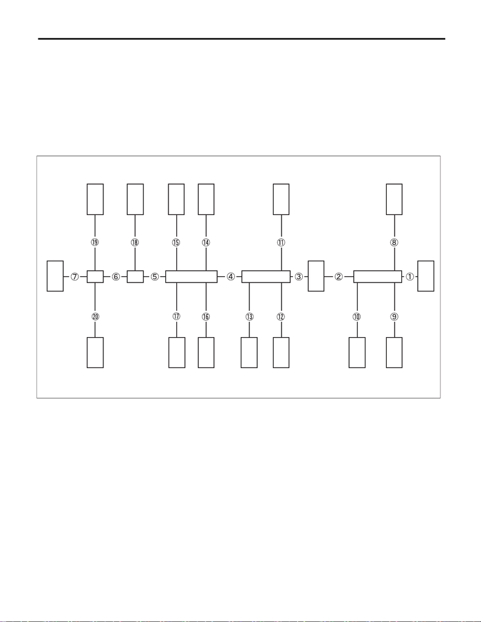

List of Diagnostic Trouble Code (DTC)

LAN SYSTEM (DIAGNOSTICS)

3) Data abnormal detection

NOTE:

If any “BUS OFF” or “NO-RECEIVE DATA” condition is detected, perform the diagnosis for these problems

first.

(1) If several modules detect the DTC for the same module, replace the detected module.

(2) If one module detects the DTC, replace the module of the detected side.

(3) If it does not return to the normal operation, re-install the module which has been replaced, and re-

place the module of the detected side.

(4) If it does not return to the normal operation, replace both modules.

2. EXAMPLE OF DTC DATA NOT RECEIVED

J/C J/C J/C

CVT

MFD

J/C J/C

LAN01445

ECM

DCCD CM

VDC CM

BODY

INTEGRATED

UNIT

AIRBAG CM

COMBINATION METER

A/C CONTROL PANEL

STEERING ANGLE SENSOR

REMOTE ENGINE STARTER

IMPACT SENSOR

AUTO HEADLIGHT

BEAM LEVELER CM

KEYLESS ACCESS CM

DATA LINK CONNECTOR

POWER STEERING CM

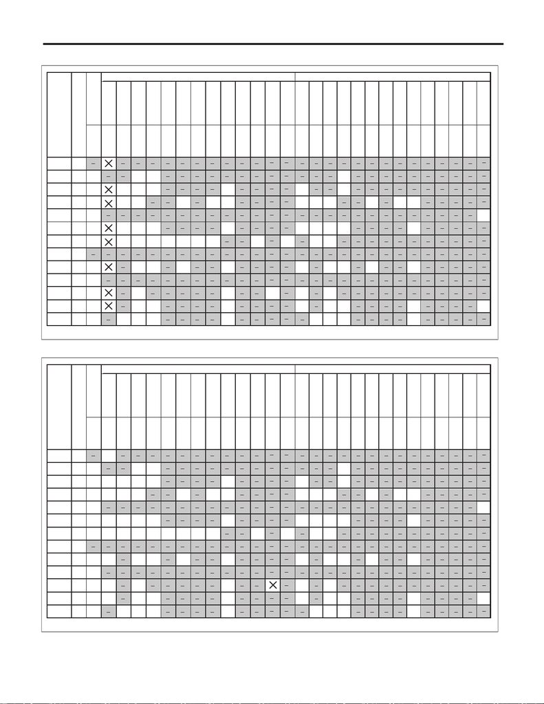

List of Diagnostic Trouble Code (DTC)

LAN SYSTEM (DIAGNOSTICS)

• Vicinity of No. 7 ECM (engine type: EJ)

• Vicinity of No. 15 steering angle sensor

LAN01469

CVT

EGI

DCCD

STR

HL

MFD

MET

KPS

EPS

BIU

VDC

CVT

EGI

DCCD

STR

HL

MFD

MET

KPS

EPS

BIU

VDC

EGI

DCCD

EPS

CVT

STR

MET

MFD

BIU

KPS

HL

VDC

U1201

U1436

U0428

U0482

U0457

U0423

U0427

U0420

U0424

U0452

U0422

U0416

U0402

U0401

U1135

U0126

U0181

U0156

U0155

U0327

U0131

U0164

U0151

U0140

U0122

U0101

U0100

U0073

(D)(C)

A/B

A/B

A/B

CAN-HS

(B)(A)

A/C

A/C

A/C

LAN01468

CVT

EGI

DCCD

STR

HL

MFD

MET

KPS

EPS

BIU

VDC

CVT

EGI

DCCD

STR

HL

MFD

MET

KPS

EPS

BIU

VDC

EGI

DCCD

EPS

CVT

STR

MET

MFD

BIU

KPS

HL

VDC

U1201

U1436

U0428

U0482

U0457

U0423

U0427

U0420

U0424

U0452

U0422

U0416

U0402

U0401

U1135

U0126

U0181

U0156

U0155

U0327

U0131

U0164

U0151

U0140

U0122

U0101

U0100

U0073

(D)(C)

A/B

A/B

A/B

CAN-HS

(B)(A)

A/C

A/C

A/C

[figure not shown]

List of Diagnostic Trouble Code (DTC)

LAN SYSTEM (DIAGNOSTICS)

3. DTC MATRIX

NOTE:

Perform the following procedure when using this chart in which the detailed trouble mode corresponds to the

trouble status.

1. Search the trouble mode that corresponds to the vehicle status from the chart.

2. Perform the repair that corresponds to the trouble mode.

HYBRID

READY

AHL

LAN01336

ECM TCM

Vehicle status 1Trouble mode 1

Trouble mode 2

Trouble mode n

Vehicle status 2

Vehicle status n

DTC reading result from each module using Subaru Select Monitor

Vehicle status 1

Vehicle status 2

Vehicle status n

Trouble mode 1

Trouble mode 2

Trouble mode n

Condition

Modules

(Which module vicinity)

Detailed location

(Which location)

Trouble mode

(What kind)

Vehicle status

(Current status)

Condition

Modules

(Which module vicinity)

Detailed location

(Which location)

Trouble mode

(What kind)

Vehicle status

(Current status)

OTHER WARNING

INDICATIONS

Indicator

[figure not shown]

List of Diagnostic Trouble Code (DTC)

LAN SYSTEM (DIAGNOSTICS)

1. CAN communication circuit open (DTC)

NOTE:

• If the module has a limit of DTC memory and the number of DTC occurrence exceeds the limit, older

DTCs are preferentially stored.

• “Trouble exists” is referred to as the status before performing inspection and repair. “Trouble existed” is

referred to as the status before performing DTC clear after repair.

U0122

U0140

U0122

U0140

U0100

U0101

U0155

U0140

U0100

U0101

U0164

U0155

U0100

U0101

U0126

U1235

U0122

U0140

U0122

U0140

U0100

U0101

U0155

U0100

U0101

U0164

U0155

U0100

U0101

U0126

U0327

U0100

U0101

U0140

U0155

U0327

U0073

U0100

U0101

U0126

U0140

U0122U0122

U0140

U0100

U0101

U0140

U0155

U0073

U0100

U0101

U0126

U0140

U0122

U0140

U0181

U0181

U0327

U0101

U0100

U0122

U0140

U0155

U0327

U0327U0327

U0073

U0100

U0126

U0140

U0122U0122

EGI CVT VDC BIU EPS KPS MET MFD HL STR DCCD

LAN01470

A/B

Control

module

A/C

Same as

above

Past

Current

Same as

above

Past

Current

Same as

above

Past

Current

None

Past

None

Current

Same as

above

Past

Current

Same as

above

Past

Current

Same as

above

Past

Current

Same as

above

Past

Current

None

Past

None

Current

Same as

above

Past

Current

None

Past

None

Current

Same as

above

Past

Current

Past

None

Current

Past

None

Current

Past

None

Current

Past

None

Current

None

Past

None

Current

Past

None

Current

Past

None

Current

Past

None

Current

Past

None

Current

None

Past

None

Current

Past

None

Current

None

Past

None

Current

Past

None

Current

None

Past

None

Current

None

Past

None

Current

None

Past

None

Current

Same as

above

Past

Current

None

Past

None

Current

None

Past

None

Current

None

Past

None

Current

Same as

above

Past

Current

None

Past

None

Current

None

Past

None

Current

None

Past

None

Current

None

Past

None

Current

None

Past

None

Current

None

Past

None

Current

None

Past

None

Current

Past

None

Current

None

Past

None

Current

None

Past

None

Current

None

Past

None

Current

Past

None

Current

Past

None

Current

None

Past

None

Current

None

Past

None

Current

None

Past

None

Current

None

Past

None

Current

None

Past

None

Current

None

Past

None

Current

None

Past

None

Current

None

Past

None

Current

None

Past

None

Current

None

Past

None

Current

None

Past

None

Current

None

Past

None

Current

Same as

above

Past

Current

None

Past

None

Current

None

Past

None

Current

None

Past

None

Current

None

Past

None

Current

None

Past

None

Current

None

Past

None

Current

None

Past

None

Current

None

Past

None

Current

None

Past

None

Current

None

Past

None

Current

None

Past

None

Current

Past

None

Current

None

Past

None

Current

Past

None

Current

None

Past

None

Current

None

Past

None

Current

Same as

above

Past

Current

Same as

above

Past

Current

Same as

above

Past

Current

Past

None

Current

Past

None

Current

Past

None

Current

Past

None

Current

None

Past

None

Current

Past

None

Current

Past

None

Current

Past

None

Current

Past

None

Current

None

Past

None

Current

Past

None

Current

None

Past

None

Current

Past

None

Current

Same as

above

Past

Current

Same as

above

Past

Current

Same as

above

Past

Current

None

Past

None

Current

Past

None

Current

Past

None

Current

Past

None

Current

Past

None

Current

None

Past

None

Current

Past

None

Current

Past

None

Current

Past

None

Current

Past

None

Current

None

Past

None

Current

None

Past

None

Current

None

Past

None

Current

Past

None

Current

Open

circuit

Open

circuit

Open

circuit

Open

circuit

Open

circuit

DTC reading result from each module using Subaru Select Monitor

Vehicle

status

Trouble

mode

Detailed

location

Condition

Hi side

Lo side

Both

sides

Hi side

Lo side

Both

sides

Hi side

Lo side

Both

sides

Hi side

Lo side

Both

sides

Hi side

Lo side

Both

sides

Trouble

exists

Trouble

existed

Trouble

exists

Trouble

existed

Trouble

exists

Trouble

existed

Trouble

exists

Trouble

existed

Trouble

exists

Trouble

existed

Communi-

cation

failure

Communi-

cation

failure

Communi-

cation

failure

Communi-

cation

failure

Communi-

cation

failure

Communi-

cation

failure

Communi-

cation

failure

Communi-

cation

failure

Communi-

cation

failure

Communi-

cation

failure

Communi-

cation

failure

Communi-

cation

failure

Communi-

cation

failure

Communi-

cation

failure

Communi-

cation

failure

Communi-

cation

failure

Communi-

cation

failure

Communi-

cation

failure

Communi-

cation

failure

Communi-

cation

failure

Communi-

cation

failure

Communi-

cation

failure

KPS

Vicinity

VDC

Vicinity

HL

Vicinity

BIU

(EGI side)

Vicinity

BIU

(VDC side)

Vicinity

[figure not shown]

List of Diagnostic Trouble Code (DTC)

LAN SYSTEM (DIAGNOSTICS)

LAN01471

EGI CVT VDC BIU A/B EPS KPS MET MFD HL STR DCCD

U0101 U0101 U0101 U0101 U0101

U0101 U0101U0101U0101U0101

U0126 U0126

U0126

U0155

U0155

U0155

U0155

U0164 U0164

U0164

U0164

U0164

U0164

U0155

U0155

U0155

U0155

U0155

U0155

U0155 U0155

U0155 U0155

U0100

U0122

U0140

U0155

U0073

U0100

U0122

U0131

U0140

U0151

U0073

U1201

U0073

U0100

U0155

U0140

U0122

U0126

Trouble

exists

Trouble

existed

Trouble

exists

Trouble

existed

Trouble

exists

Trouble

existed

Trouble

exists

Trouble

existed

Trouble

exists

Trouble

existed

Open

circuit

Open

circuit

Open

circuit

Open

circuit

A/C

Vicinity

Open

circuit

Condition

DTC reading result from each module using Subaru Select Monitor

Control

module

Vehicle

status

mode

Detailed

location

Current

None

Past

None

Current

None

Past

None

Current

None

Past

None

Current

None

Past

None

Current

None

Past

None

Current

None

Past

None

Current

None

Past

None

Current

None

Past

None

Current

None

Past

None

Current

None

Past

None

Current

None

Past

None

Current

None

Past

None

Current

None

Past

None

Current

None

Past

None

Current

None

Past

None

Current

None

Past

None

Current

None

Past

None

Current

None

Past

None

Current

None

Past

None

Current

None

Past

None

Current

None

Past

None

Current

None

Past

None

Current

None

Past

None

Current

None

Past

None

Current

None

Past

None

Current

Past

Current

None

Past

None

Current

Past

Current

None

Past

None

Current

None

Past

None

Current

None

Past

None

Current

Past

Current

None

Past

Current

None

Past

None

Current

None

Past

None

Current

None

Past

None

Current

None

Past

None

Current

None

Past

None

Current

None

Past

Current

None

Past

None

Current

None

Past

Current

None

Past

None

Current

None

Past

Current

None

Past

None

Current

None

Past

None

Current

None

Past

Current

None

Past

None

Current

None

Past

None

Current

None

Past

None

Current

None

Past

None

Current

Past

Current

Past

Current

None

Past

None

Current

Past

Current

None

Past

None

Current

Past

Current

Past

Current

Past

Current

None

Past

None

Current

None

Past

None

Current

None

Past

None

Current

Past

Current

None

Past

Current

None

Past

Current

None

Past

None

Current

None

Past

Current

None

Past

None

Current

None

Past

Current

None

Past

Current

None

Past

Current

None

Past

None

Current

None

Past

None

Current

None

Past

None

Current

None

Past

Current

None

Past

None

Current

None

Past

None

Current

Past

Current

None

Past

Current

None

Past

None

Current

None

Past

None

Current

Past

Current

None

Past

None

Current

None

Past

None

Current

None

Past

None

Current

None

Past

None

Current

None

Past

None

Current

None

Past

None

Current

None

Past

None

Current

None

Past

Current

None

Past

None

Current

None

Past

None

Current

None

Past

None

Current

None

Past

Current

None

Past

None

Current

None

Past

None

Current

None

Past

None

Current

None

Past

None

Current

None

Past

None

Current

None

Past

None

Current

Past

Same as

above

Same as

above

Same as

above

Same as

above

Same as

above

Same as

above

Current

None

Past

None

Current

Past

Current

None

Past

None

Current

Past

Current

None

Past

None

Current

Past

Current

Past

Current

None

Past

None

Current

None

Past

None

Current

None

Past

None

Current

None

Past

None

Current

None

Past

Current

None

Past

Current

None

Past

None

Current

None

Past

Current

None

Past

None

Current

None

Past

Current

None

Past

None

Current

None

Past

Current

None

Past

Current

None

Past

None

Current

None

Past

None

Current

None

Past

None

Current

None

Past

None

Current

None

Past

Hi side

Lo side

Both

sides

Hi side

Lo side

Both

sides

Hi side

Lo side

Both

sides

Hi side

Lo side

Both

sides

Hi side

Lo side

Both

sides

Commu-

nication

failure

Commu-

nication

failure

Commu-

nication

failure

Commu-

nication

failure

Commu-

nication

failure

Same as

above

Same as

above

Same as

above

Same as

above

Same as

above

Same as

above

Same as

above

Same as

above

Same as

above

Same as

above

A/C

MFD

Vicinity

MET

Vicinity

STR

Vicinity

CVT

Vicinity

[figure not shown]

List of Diagnostic Trouble Code (DTC)

LAN SYSTEM (DIAGNOSTICS)

LAN01472

U0100

U0100U0100U0100

U0100U0100U0100

U0100U0100

U0100

U0073

U1135

U1135

U0131

U0131

U0151

U0151

U0122

U0126

U0073

U0073

U0100

U0122

U0140

U0155

U1201

EGI CVT VDC BIU A/B EPS KPS MET MFD HL STR DCCD

Trouble

exists

Trouble

existed

Trouble

exists

Trouble

exists

Trouble

existed

Trouble

existed

Trouble

exists

Trouble

existed

Open

circuit

Open

circuit

Open

circuit

Open

circuit

Condition

DTC reading result from each module using Subaru Select Monitor

Current

None

Past

None

Current

None

Past

None

Current

None

Past

None

Current

None

Past

None

Current

None

Past

None

Current

None

Past

None

Current

None

Past

None

Current

Past

Current

None

Past

None

Current

None

Past

None

Current

None

Past

None

Current

None

Past

None

Current

None

Past

None

Current

None

Past

None

Current

None

Past

None

Current

None

Past

None

Current

None

Past

None

Current

None

Past

None

Current

None

Past

None

Current

None

Past

None

Current

None

Past

Current

None

Past

None

Current

None

Past

None

Current

None

Past

None

Current

None

Past

None

Current

None

Past

None

Current

None

Past

None

Current

None

Past

None

Current

None

Past

None

Current

None

Past

None

Current

None

Past

None

Current

None

Past

None

Current

Past

Current

None

Past

None

Current

None

Past

None

Current

None

Past

None

Current

None

Past

None

Current

None

Past

None

Current

None

Past

None

Current

None

Past

None

Current

None

Past

None

Current

None

Past

None

Current

None

Past

None

Current

None

Past

Current

None

Past

None

Current

None

Past

Current

None

Past

None

Current

None

Past

None

Current

None

Past

None

Current

None

Past

None

Current

None

Past

None

Current

None

Past

None

Current

None

Past

None

Current

None

Past

None

Current

None

Past

None

Current

None

Past

None

Current

None

Past

None

Current

None

Past

None

Current

Past

Current

None

Past

None

Current

None

Past

None

Current

None

Past

None

Current

None

Past

None

Current

None

Past

None

Current

None

Past

None

Current

None

Past

None

Current

None

Past

None

Current

None

Past

None

Current

None

Past

None

Current

None

Past

None

Current

None

Past

Current

None

Past

None

Current

None

Past

None

Current

None

Past

None

Current

Past

Current

Past

Current

Past

Current

None

Past

None

Current

Past

None

Current

Past

Current

Past

Current

Past

Current

None

Past

None

Current

None

Past

None

Current

None

Past

None

Current

Past

Current

None

Past

Current

None

Past

Current

None

Past

Current

None

Past

Current

None

Past

None

Current

None

Past

None

Current

None

Past

Current

None

Past

Current

None

Past

Current

None

Past

None

Current

None

Past

None

Current

None

Past

None

Current

None

Past

Current

None

Past

Control

module

Vehicle

status

mode

Detailed

location

Hi side

Lo side

Both

sides

Hi side

Lo side

Both

sides

Hi side

Lo side

Both

sides

Hi side

Lo side

Both

sides

Same as

above

Same as

above

Same as

above

Same as

above

Same as

above

Same as

above

Same as

above

Same as

above

Commu-

nication

failure

Commu-

nication

failure

Commu-

nication

failure

Commu-

nication

failure

Same as

above

Same as

above

Same as

above

A/C

A/B

Vicinity

EPS

Vicinity

DCCD

Vicinity

EGI

Vicinity

[figure not shown]

List of Diagnostic Trouble Code (DTC)

LAN SYSTEM (DIAGNOSTICS)

2. CAN communication circuit open (indicator)

NOTE:

“Trouble exists” is referred to as the status before performing inspection and repair. “Trouble existed” is re-

ferred to as the status before performing DTC clear after repair.

AWD

EPS

EPB

ABS

VDC

AWD

EPS

EPB

ABS

VDC

LAN01473

Control module

Detailed location

Trouble mode

Vehicle status

Control module

Detailed location

Trouble mode

Vehicle status

CHARGE WARNING

OIL PRESSURE

HILL HOLD

ACCESS KEY WARNING

SECURITY INDICATOR

REMAINING FUEL GAUGE

AUTO HEADLIGHT BEAM LEVELER

CHARGE WARNING

OIL PRESSURE

HILL HOLD

ACCESS KEY WARNING

REMAINING FUEL GAUGE

Trouble

exists

Trouble

existed

Trouble

exists

Trouble

existed

Condition

Condition

Indicator

Open

circuit

A/C

Vicinity

AUTO HEADLIGHT BEAM LEVELER

SECURITY INDICATOR

AIRBAG

AIRBAG

: Off

: Blink

: Illuminate

Hi side

Lo side

Both

sides

Open

circuit

Hi side

Lo side

Both

sides

Trouble

exists

Trouble

existed

Open

circuit

Hi side

Lo side

Both

sides

Trouble

exists

Trouble

existed

Open

circuit

Hi side

Lo side

Both

sides

Trouble

exists

Trouble

existed

Open

circuit

Hi side

Lo side

Both

sides

Trouble

exists

Trouble

existed

Open

circuit

Hi side

Lo side

Both

sides

Trouble

exists

Trouble

existed

Open

circuit

Hi side

Lo side

Both

sides

Trouble

exists

Trouble

existed

Trouble

exists

Trouble

existed

Open

circuit

Hi side

Lo side

Both

sides

Open

circuit

Hi side

Lo side

Both

sides

Trouble

exists

Trouble

existed

Open

circuit

Hi side

Lo side

Both

sides

Trouble

exists

Trouble

existed

Open

circuit

Hi side

Lo side

Both

sides

Trouble

exists

Trouble

existed

Open

circuit

Hi side

Lo side

Both

sides

Trouble

exists

Trouble

existed

Open

circuit

Hi side

Lo side

Both

sides

Trouble

exists

Trouble

existed

Open

circuit

Hi side

Lo side

Both

sides

Indicator

VDC OFF

EMPTY

BRAKE

AT OIL TEMP

CHECK ENGINE

EMPTY

BRAKE

AT OIL TEMP

CHECK ENGINE

VDC OFF

VDC

Vicinity

SMT

Vicinity

AHL

Vicinity

MFD

Vicinity

MET

Vicinity

STR

Vicinity

CVT

Vicinity

A/B

Vicinity

EPS

Vicinity

DCCD

Vicinity

EGI

Vicinity

BIU

(EGI

side)

Vicinity

BIU

(VDC

side)

Vicinity